# Shark Migration and Surface Temperature

Andrew Gans, Ana Pirosca, Jaan Selod, Ava Skogstrom

2023-12-04

# Introduction:

Shark migration patterns are incredibly important for the survival and the health of marine ecosystems. Aside from serving as ‘flagship species’ that facilitate the raising of awareness and financial support for conservation of coral reefs and marine life, sharks also operate as top predators that can initiate trophic cascades according to Heithaus et al. (2008). Trophic cascades are vital for controlling relative populations of other species down the food chain and therefore affect the natural sources of food–often related directly to health and biodiversity of the entire ecosystem.

However, rising surface water temperatures, a stark reality of climate change, has already significantly affected marine life. Previous research has established the undeniable link between warming waters and altered shark behavior. Studies by “Ocean Acidification and Global Warming Impair Shark Hunting Behaviour and Growth” (2015) suggest that growing ocean acidification and global warming can impair shark hunting and growth, potentially resulting in dangerous trophic cascades. This can have potentially catastrophic implication for regions where water is heating up significantly year to year. For example, the New England region recorded warming water temperatures up to 3 degrees Fahrenheit since 1901 according to “New England Coastal Waters Warming More Than Anywhere Else in u.s.” (2019).

There is little understood about the migratory patterns of sharks in the northeastern regions as temperature of water rise. Which begs the question: How exactly does surface water temperature influence shark migration patterns? In order to answer this question we combined observed data of shark migratory patterns over time with information about temperature of water over a specified area of the Northeastern region. Using statistical analysis we were able to observe the impact of drastically increasing water temperatures on shark behavior across different species in order to understand the universal relationship on shark behavior.

# Methods:

The area of interest, encompassing approximately the Gulf of Maine region, was identified and then delineated using the ‘measure a distance’ tool in Google Maps. This defined four sets of latitude and longitude coordinates, which were subsequently rounded to the nearest integer for ease of analysis. Occurrence data from the Global Biodiversity Information Facility (GBIF) was filtered to obtain all human Elasmobranchii observations in the area of interest between 2000 and 2023, then further filtered to include migratory shark species. Sea surface temperature data was retrieved from the National Oceanic and Atmospheric Administration (NOAA)’s Optimum Interpolation Sea Surface Temperature (OISST) dataset by Dr. Kenaley, extracting data from the region of interest. Spatial analysis for temperature was merged with observations to conduct linear mixed effects modeling and subsequently analysis of variance on the data and model predictions.

# Results:

## 1. Identifying Species and Area of Interest:

Table 1: Rounded Coordinates for Region of Interest

| name | lat | long |
| --- | --- | --- |
| low_left | 41 | -72 |
| top_left | 45 | -72 |
| top_right | 45 | -66 |
| low_right | 41 | -66 |

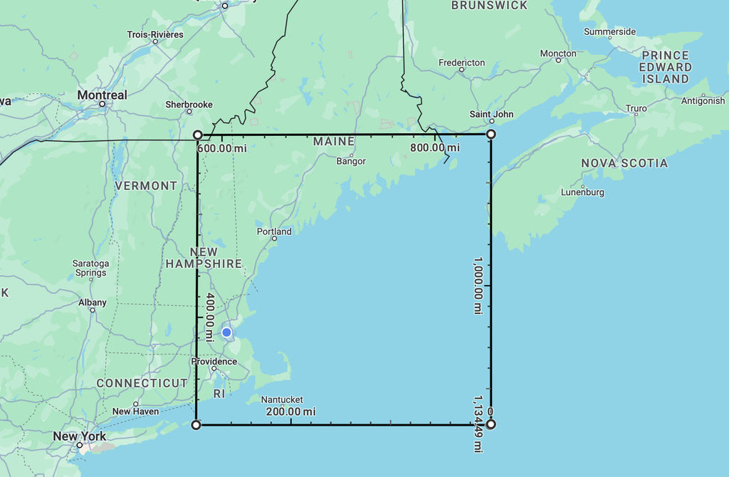

Figure 1: Screenshot of region of interest

Table 2: Migratory Shark Species in the Area of Interest

| scientific_name | common_name |
| --- | --- |
| Cetorhinus maximus | basking shark |
| Isurus oxyrinchus | shortfin mako |
| Mustelus canis | smooth dogfish |
| Lamna nasus | porbeagle |
| Squalus acanthias | spurdog |
| Carcharias taurus | sand tiger shark |
| Carcharinus plumbeus | sandbar shark |
| Carcharodon carcharias | white shark |
| Prionace glauca | blue shark |
| Carcharinus obscurus | dusky shark |

Occurence data indicated that a number of shark species have been identified in our region of interest since 2000. Using information from the National Oceanic and Atmospheric Administration, we can narrow down the list of species to those that exhibit migratory behavior between the area of interest and the mid-Atlantic/Southeast waters (“Atlantic Highly Migratory Shark Species” (2023)).